# Morloc benchmarks

Zebulun Arendsee

2025-01-10

# Benchmark comparing morloc, Snakemake and Nextflow

The runtime performance of a component workflow can be modeled as follows:

$$t(n,k) = S + Lk + n(Q + Rk + Ik)$$

where * $t$ - (s) total pipeline runtime * $n$ - (unit) number of nodes in the pipeline * $k$ - (Mb) size of the data that is passed between each node (assuming data size is the same between all nodes) * $S$ - (s) the one-time cost for initializing the pipeline * $L$ - (s/Mb) the one-time cost for loading an initial data file of size `k` * $Q$ - (s) the constant cost of starting a node * $R$ - (s/Mb) the runtime of running node function per Mb of input * $I$ - (s/Mb) the cost for moving data to/from a node per Mb

The $L$ and $R$ terms, measures of the time required to load initial data and run each core computation in ecah node, is mostly independent of the workflow. Parallelism and scaling are of course also important to runtime. This includes full utilization of individual machines and the distrubution of work between machines. The model above could be generalized to describe parallelism.

The performance of workflow managers can be compared by estimating their $S$, $Q$, and $I$ values.

The initial program start time, $S$, is a single constant added to total runtime of a few seconds for Nextflow and tens to hundreds of milliseconds for morloc and Snakemake. A few seconds of extra latency is not a major issue for computations that run more than a few minutes. But this latency qualitatively changes the field of use cases for the workflow language. For example, a few seconds of latency means that the workflow is inappropriate for interactive use in running small jobs as a CLI tool or on the backend of a web service. On a CLI, a half second delay is painfully noticeable. This can be especially irritating when requesting usage or version info from a tool and then having to wait for a print statement. Still, for scientific computing, this is the least important of the three metrics.

The data transfer time, $I$, is the time it takes to transfer a Mb of data between nodes. This time includes the costs of transforming data from storage formats to native data structures. $I$ can be a bottleneck with large datasets need to be passed between many nodes that do relatively small operations on them. Passing a dataset from one function to another function by reference is a nearly zero cost operation. This is supported for `morloc` within-language calls. For foreign calls, `morloc`, reformats that data, copies it into shared memory, and sends the relative pointer to the foreign language server. In Nextflow, data is streamed from one process to the next. Streaming is fairly efficient, and Nextflow is interop in this benchmark (where the data is just a long string that requires to validation or formatting) is nearly as fast as `morloc` data transfer.

The parameters of this model can be calculated by measuring the runtime of a simple linear pipeline. I am using the python program `hyperfine` for benchmarking the runtime of the CLI programs. This can be pretty noisy, especially for Nextflow with is very long startup time. The benchmarking pipeline starts with a text file of varying size (from 0Mb to 160Mb). The file is loaded and then passed through a chain of functions that each performa a small operation on it. This operation requires copying the entire string and modifying it. I can estimate all the parameters in the runtime model with four benchmarks:

1. Estimate $L$ by running single-language benchmarks (no manager) that loads datasets of different sizes but sets the number of iterations (nodes in the loop) to 0. This means data is loaded and then nothing is done with it. Using linear regression, I calculate the slope of time versus filesize. The slope equals the $L$ parameter for the given language (e.g., R, Python, C++).
2. Estimate $R$ by running a series of single-language benchmarks with constant filesize but varying number of iterations. Now the slope will be equal to the runtime cost per Mb of input.
3. To estimate $Q$ and $S$, I set the data size, $k$, to 0 and benchmark runtimes for number of iteration, $n$, from 0 to 16. The intercept is $S$, the pipeline startup cost, and the slope is $Q$, the node startup cost.

$$t(n,k=0) = S + Lk + n(Q + Rk + Ik) = S + nQ$$

4. To estimate $I$, we set the number of iterations to $n=4$ and let the data size, $k$, vary. We can then use the previously estimated values for $S$, $Q$, $L$, and $R$, along with the estimated intercept and slope from the benchmarks, to solve for $I$, as below:

$$I = (slope - L - 4R) / 4$$

## Estimate $L$ - data loading cost per Mb

Set $n=0$ for single-language implementations. Each of these runs loads the input file and then quits. The `morloc`, `snakemake`, and `nextflow` programs use the same code for reading input, so the obtained coefficients should be transferable. The runtime is:

$$t_{n=0} = S_{lang} + L k$$

## Estimate $R$ - functional runtime cost per Mb

In the single-language implementations, set the number of loops to $n=20$ and run with variable size data. This allows the estimation of $R$, the runtime. All workflow languages use the same functions for in each loop, so $R$ should be transferable.

The slope is file loading, $L$, time plus $n$ times the node run time, $R$. So $R$ can be calculated from the slope as follows:

$$R = (\beta_{1} - L) / n$$

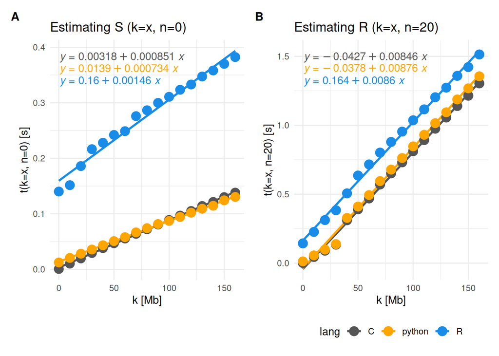

Fig 1. Benchmarks used to estimate L (load time) and R (function runtime). L corresponds directly to the slope of plot A. R is equal to the slope from plot B minus L and divided by n=20. R is the cost of running each function per Mb of input.

Table 1. L and R estimates

| Load Time (L) [s/Mb] | Runtime (R) [s/Mb] |
| --- | --- |
| 0.0009 | 4e-04 |
| 0.0007 | 4e-04 |
| 0.0015 | 4e-04 |

## Estimate $Q$ and $S$ - cost of starting a pipeline and a single node

Set $k=0$ and estimate the constant cost of making an interop call. Here we compare all of our workflow languages when data of 0 length is passed between them. This measures the overhead of a call between nodes.

$$t(n,k=0) = S + Lk + n(Q + Rk + Ik) = S + nQ$$

The runtime is equal to pipeline startup time, $S$, plus the number of loops, $n$, times the node start cost, $Q$. So benchmarking at many different values for $n$, we can estimate $S$ as the intercept and $Q$ as the slope coefficient.

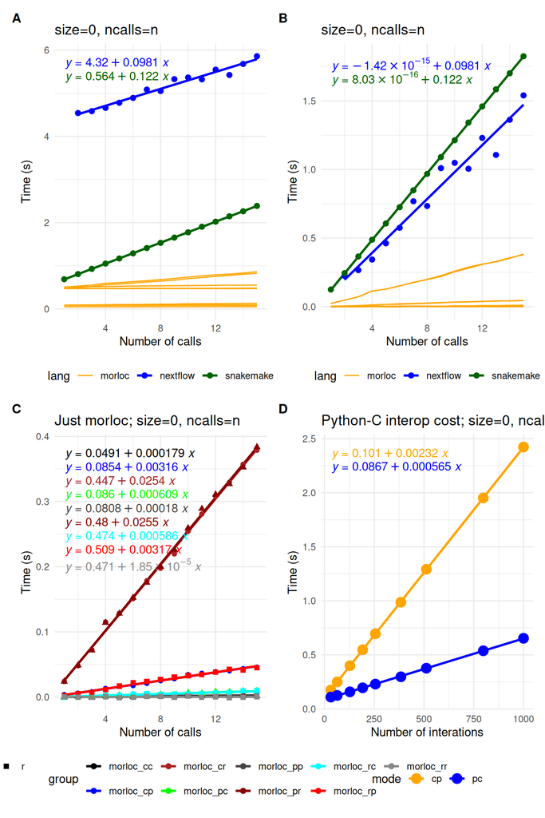

Fig 2

We see R interop is quite slow, relative to Python. This is may be a surmountable implementation issue. Python and C interop is limited by the speed messages can be passed over UNIX domain sockets.

Running benchmarks for larger numbers of iterations with just Python and C interop let’s us make a better estimate of their interop:

The overhead of a single function call in a one-language morloc program is beyond the resolution limits of our benchmark. There is some overhead, since morloc, as currently implemented, creates wrappers around the functions.

Repeating the main runtime equation and definitions:

$$t(n,k) = S + Lk + n(Q + Rk + Ik)$$

where * $t$ - (s) pipeline runtime * $n$ - (unit) number of nodes in the pipeline * $k$ - (Mb) size of the data that is passed between each node (assuming data size is the same between all nodes) * $S$ - (s) the one-time cost for initializing the pipeline * $L$ - (s/Mb) the one-time cost for loading an initial data file of size `k` * $I$ - (s/Mb) the cost for moving data to/from a node per Mb * $Q$ - (s) the constant cost of starting a node * $R$ - (s/Mb) the runtime of running node function per Mb of input

Now we set $n=4$

$$t(n=4,k) = S + Lk + 4(Q + Rk + Ik)$$

And subsitute in the intercept and slope for our benchmarks:

$$t(k | n=4) = b0 + b1 k$$

where the intercept is ($b0 = S + 4Q$) and the slope is ($b1 = L + 4R + 4I$)

We have already estimated $L$ and $R$, so now we can estimate $I$ (the cost of moving data to/from a node per Mb).

$$I = (b1 - L - 4R) / 4$$

```
##               group             I
## 1         morloc_rr -1.004131e-04
## 2         morloc_cc -8.191926e-05
## 3         morloc_pp  1.787993e-05
## 4   nextflow_testlc  1.605775e-03
## 5         morloc_rp  1.795150e-03
## 6         morloc_pr  1.987868e-03
## 7         morloc_cp  2.130390e-03
## 8         morloc_cr  2.284322e-03
## 9         morloc_rc  2.497238e-03
## 10        morloc_pc  2.538502e-03
## 11 snakemake_testlt  3.347411e-03
## 12 snakemake_testlc  3.386956e-03
```

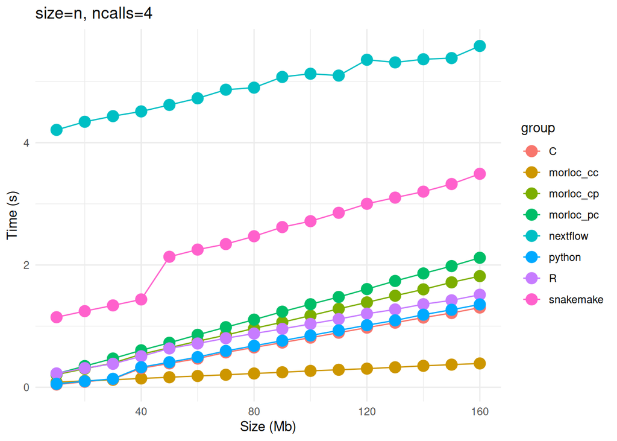

Table 2. S and Q estimates

[output not shown]

Table 3. S and Q estimates as speed multiples of the worst

| group | S: program start [s] | Q: node start [s] | I: transfer cost [s/Mb] | R: node runtime [s] | L: load time [s] |
| --- | --- | --- | --- | --- | --- |
| morloc_cc | 88.016909 | 677.329169 | NA | 1.053884 | 3.841147 |
| morloc_cp | 50.586055 | 38.498198 | 1.589829 | 1.053884 | 3.841147 |
| morloc_cr | 9.648933 | 4.792497 | 1.482697 | 1.053884 | 3.841147 |
| morloc_pc | 50.224623 | 199.538818 | 1.334234 | 1.000000 | 3.644751 |
| morloc_pp | 53.444759 | 673.898642 | 189.427796 | 1.000000 | 3.644751 |
| morloc_pr | 8.986437 | 4.761783 | 1.703814 | 1.000000 | 3.644751 |
| morloc_rc | 9.113151 | 207.644842 | 1.356281 | 1.124080 | 4.096993 |
| morloc_rp | 8.485553 | 38.307784 | 1.886726 | 1.124080 | 4.096993 |
| morloc_rr | 9.160247 | 6587.827487 | NA | 1.124080 | 4.096993 |
| nextflow_testlc | 1.000000 | 1.238762 | 2.109234 | 1.000000 | 3.644751 |
| snakemake_testlc | 7.660763 | 1.000000 | 1.000000 | 1.000000 | 3.644751 |